# AlgEpi question catalog

Johannes Hausmann, Luis Kress

2022-05-24

> Written and answered on a best effort basis. It might contain wrong answers. Copying without questioning leads to your ruin!

## 1. Introduction into Epigenetics

### What is epigenetics?

- studies on heritable changes
  - of gene expression
  - of cellular phenotype
- caused by mechanisms other than changes in the nucleotide sequence

### What happens in DNA methylation?

- methylation of the 5th C-atom of cytosine
  - 5-Methylcytosine
- occurring in the CpG context
  - both strands of the DNA are recognized and methylated
- dynamic process
  - active methylation (*de novo*: DNMT3a/b, conservation: DNMT1)
  - de-methylation (TET1/2/3, BER)

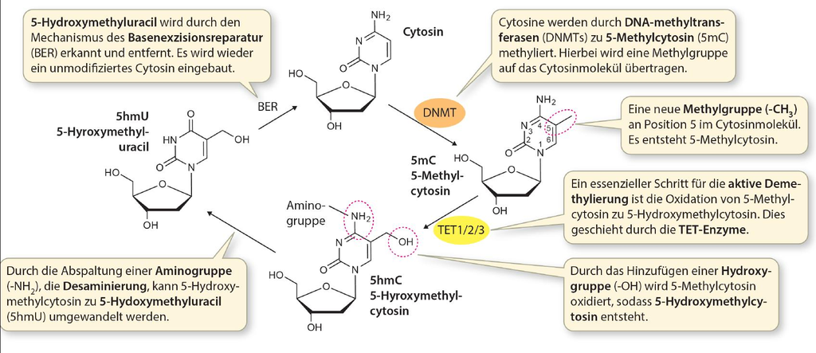

Methylation – De-methylation path of cytosine

- DNA methylation is also used to define the parental strand during replication

### How can DNA methylation affect gene expression?

- CpG islands are cytosine and guanin rich regions in the genome
- conserved region in or close to the promoter
- unmethylated = gene is active
  - TF can bind → gene is expressed
- methylated = gene is silenced
  - TF can not bind → gene not expressed
- Methylated DNA can interfere (block or enhance) the binding of transcription factors
- methyl binding proteins
  - recognize methylated CpG sites
  - recruit histone modifying enzymes → chromatin changes

### What are histone modifcations?

- DNA is wrapped around Histones (protein of a certain type)
  - DNA + core histones → nucleosome
- Addition of H1 (linker histone) → 30nm fibre (less active genes)
- Biochemical modifications of core histones
  - influence affinity of linker histone (H1)  
    → consequence is change in chromatin structure
- Histone tails (N-terminal) get modified
  - position and type influence the outcome (activation or repression of transcription)

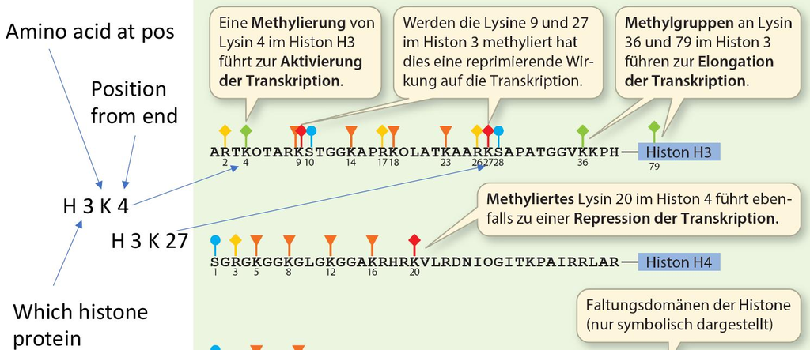

Type of histone modifications and naming convention

### Which histone modifications are associated with active transcription or heterochromatin?

- Acetylation of histones at N-terminal ends is associated with transcriptional activity
- Lysins in terminal ends lead to positive charge that interacts with negative charge of DNA
- Acetylated lysins reduces positive charge
  - Loss of affinity to DNA
- Change of charge also effects interaction of nucleosomes among each other
  - Loss of 30nm filaments
- Good overview: [Link to overview table (https://doi.org/10.1186/s13059-019-1870-5)](https://genomebiology.biomedcentral.com/articles/10.1186/s13059-019-1870-5/tables/1)

### What is Waddington‘s epigenetic landscape model?

- 1957: Conrad Waddington’s concept of an epigenetic landscape to represent the process of cellular decision-making during development. At various points in this dynamic visual metaphor, the cell (represented by a ball) can take specific permitted trajectories, leading to different outcomes or cell fates.
- Dellular differentiation can be considered an epigenetic phenomenon, largely governed by changes in “epigenetic landscape” rather than alterations in genetic inheritance

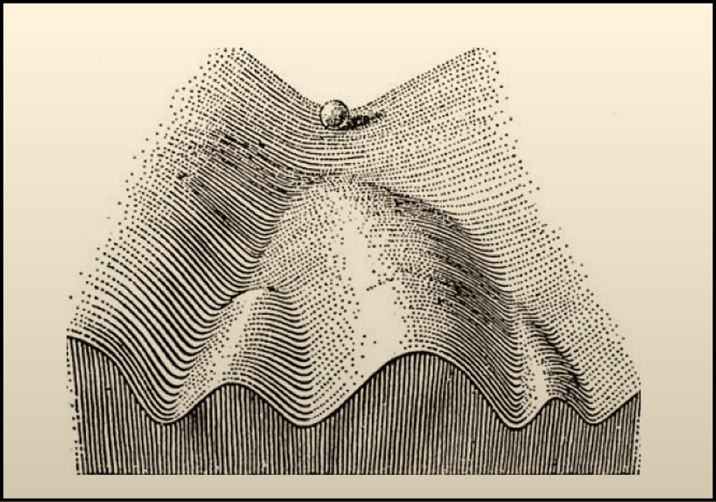

Waddington’s Classical Epigenetic Landscape

- Chromatin structure of germ cells loosened and DNA methylation is reduced to a minmum → totipotent cell types
- cell-type specific pattern established in following cell division cycles → cell-type specific gene expression

### What is imprinting?

- Allele-specific expression of a genev (either from the maternal or paternal allele) via CpG methylation

### Explain how mosaic colouring of cat fur comes about?

- Random activation or inactivation during embryonic development of one of the X chromosomes, where the responsible gene for fur coloring is located

## 2. Understanding gene expression with RNA sequencing

### What is RNA-seq?

- Sequencing of mature mRNA molecules
- Fragmentation of transcripts and reverse transcription to cDNA (hexamer priming)
- Generation of ds-cDNA fragments and high throughput sequencing
- Can be used to estimate gene expression or identify novel transcriptional changes

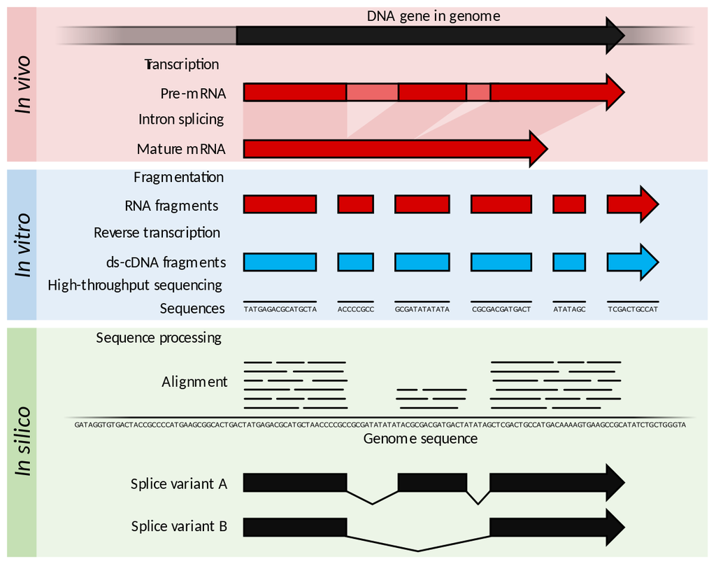

RNA-seq experiment workflow

### How to obtain RNA counts?

- Two strategies to map and quantify RNA-seq reads
1. Mapping to the transcriptome
   - Reduced search space
   - Can only assign reads if they originate from known transcripts
   - No novel transcripts
2. Mapping to the genome
   - Large search space for alignment
   - Methods need to be splice-aware
   - *in silico* splice reads to consider introns
- Transcript counts are aggregated to obtain gene level counts
- Genome mapping → count reads per gene bin

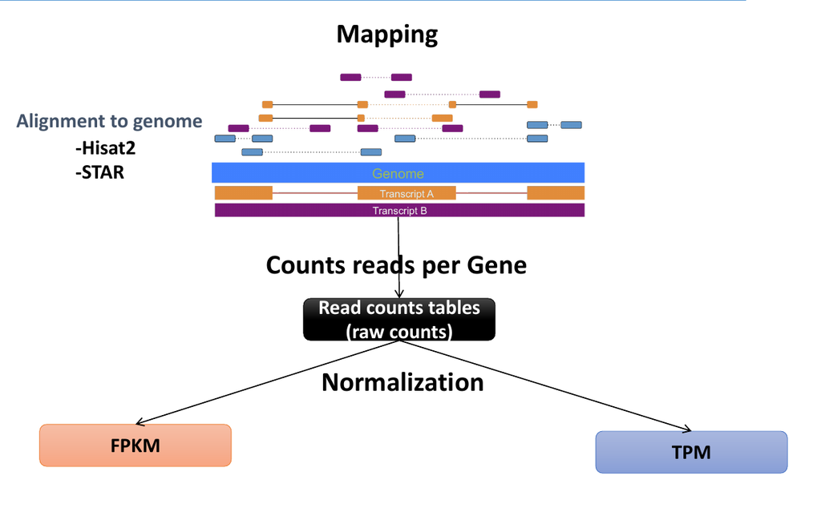

RNA-seq counts

### Why do we need to normalize RNA-seq read counts?

- gene expression measurement
  - to compare expression between genes
  - to compare expression of a gene between samples
- An estimation of the average copy number of a gene‘s RNAs
- We need to consider
  - Differences in gene length  
    ↝ longer genes produce more fragments
  - Differences in library size
    - Number of reads obtained per experiment by the sequencer is different

### What are TPM and RPKM normalization?

- Metrics to adjust raw read counts for gene length and sequencing depth
- Very similar but calculated in different orders
- RPKM (Reads Per Kilobase per Million Mapped reads)
  - single end sequencing → FPKM for paired end reads
  - Scale read counts by number of reads mapped and multiplied with scaling factor (10^9)

### Why is TPM better?

### How to quantify transcript expression?

### What is the effective length of a transcript?

### Which biases does Salmon take into account?

## 3. Analysis of differential expression data and interpretation

### Which normalization does DEseq2 use?

### What is the advantage of the negative binomial compared to the Possion distribution, when looking at counts?

### What is a p-value?

### What does FDR mean

### Why do I need to do FDR?

### How does DEseq2 fit the dispersion for genes?

### What is an MA-plot, and how to read it?

### What is the Gene Ontology?

### How is functional enrichment estimated?

## 4. Analysis of ChIP-seq data

### What is ChIP-seq?

### Why do we need to normalize ChIP-seq read counts?

### What is indirect binding?

### Explain basic quality steps for ChIP-seq data?

### How does peak calling with MACS2 work?

### What are the 6 core histone modifications?

### How can ChIP-seq data be used to locate tissue-specifc enhancers?

### Mention approaches for differential peak calling!

## 5. Analysis of DNA methylation data

### Why does sodium bisulfite treatment allow DNA methylation analysis?

### Why is WGBS called the gold standard in DNA methylation analysis?

### Why is bisulfite-seq data difficult to analyze?

### What is the asymmetric mapping problem?

### How do reduced representation mappers perform alignment?

### What are PMDs and how does MethylSeekR find them?

### How does RnBeads do differential methylation detection?

### Why is epigenetics on cell-free DNA interesting?

## 6. Analysis of open-chromatin data

### What does open-chromatin mean?

### Which assays are commonly used to profile open-chromatin regions?

### How is NOMe-seq different to other assays?

### What is the underlying idea of the gNOMeHMM approach for?

### How does JAMM use mixture models for detecting peaks?

### Which aspect of ATAC-seq data is specifically modelled by the HMM in the HMMRATAC method?

### Which of the two assays are more similar ATAC-, NOMe- and, DNase1-seq and why?

### How can you compute overlap between peak datasets?

- Since peaks are just intervalls of genomic regions you can use BEDtools to intersect the region to find overlaps